# hw10

Jason Kang

4/30/2021

1. Prepare the data for the network analysis (create a separate edge and node list) Notes: -Q2 contain people’s names. Since it’s anonymous, the names became numbers. -Q3_1 - Q3_40 all asks: Tell me some information about the relationships you have with other people in this class -Q4 asks: Are you introverted or extroverted? 1 = introverted, 2 = middle ground, 3 = extroverted

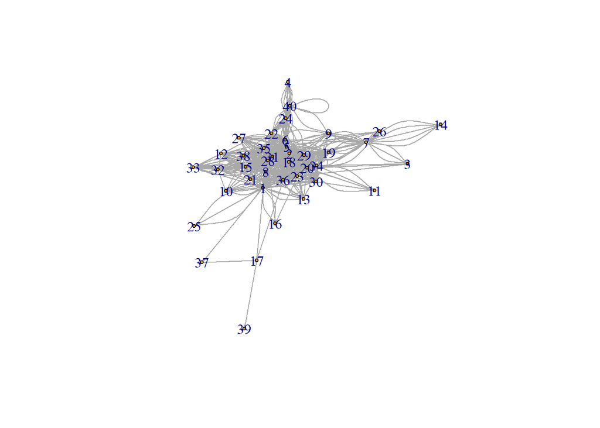

```r
#Preparing the data
network_data <- read_excel("hw10.xlsx")
# nodelist
nodelist0 <- read_excel("hw10.xlsx")[-1,]

colnames(nodelist0) <- c("ID",1:40, "personality")

#nodelist <- nodelist0 %>%
#  select(ID,personality) %>%
# drop_na()

# create a dataset for nodelist
nodelist <- read_excel("for_nodelist.xlsx")

# edgelist
# out-tie is the participant
# in-ties are the people the respondent are answering questions about
# tie-type: 1) I have texted in the last 7 days, 2) I have met during my time in MBDS, 3) Is my friend,
# 4) I asked for advice/help, 5) Asks me for help/advice

edge <- nodelist0 %>%
  pivot_longer(col = -c(ID, personality), names_to = "in-tie", values_to = "value")

rename(edge, c("out-tie" = "ID")) -> edge

edgelist <- separate_rows(edge, value, sep = ",")

edgelist <- edgelist %>%
  select(!personality)

edgelist <- rename(edgelist, setNames("value","tie_type"))

edgelist <- edgelist %>%
  drop_na()

newnetwork <- graph_from_data_frame(d = edgelist, vertices = nodelist, directed = TRUE)
plot(newnetwork, edge.arrow.size = 0.1, vertex.size = 3)
```

#2) Calculate measures of centrality and similarity in networks depending on the type of tie? Which tie type generates the most similar network in terms of introversion? Which tie type is the most dissimilar?

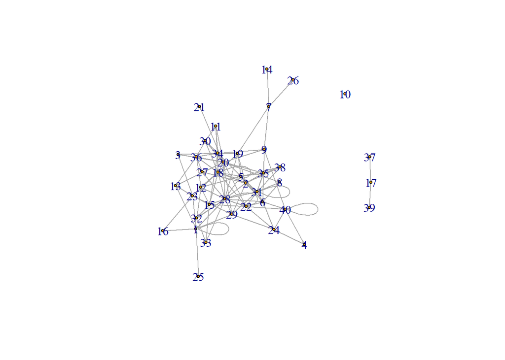

```r
#for tie-type1
#network
edgelist1 = subset(edgelist, tie_type == 1)
newnetwork1 <- graph_from_data_frame(d = edgelist1, vertices = nodelist, directed = TRUE)
plot(newnetwork1, edge.arrow.size = 0.1, vertex.size = 3)
```

```r
#Degree Centrality
degree(newnetwork1, mode="in")
```

```
##  1  2  3  4  5  6  7  8  9 10 11 12 13 14 15 16 17 18 19 20 21 22 23 24 25 26
##  3  6  3  2  8  7  0  3  5  0  4  6  4  1  4  2  0 10  6  4  1  8  1  2  1  1
## 27 28 29 30 31 32 33 34 35 36 37 38 39 40
##  3 10  7  4  6  2  3  5  5  4  1  2  1  3
```

```r
centr_degree(newnetwork1, mode="in", normalized=T)
```

```
## $res
##  [1]  3  6  3  2  8  7  0  3  5  0  4  6  4  1  4  2  0 10  6  4  1  8  1  2  1
## [26]  1  3 10  7  4  6  2  3  5  5  4  1  2  1  3
##
## $centralization
## [1] 0.1615385
##
## $theoretical_max
## [1] 1560
```

```r
degree(newnetwork1, mode="out")
```

```
##  1  2  3  4  5  6  7  8  9 10 11 12 13 14 15 16 17 18 19 20 21 22 23 24 25 26
##  6  8  0  0  9  9  4  0  0  0  0  0  0  0  7  0  2 11  0 14  0  0  8  5  0  0
## 27 28 29 30 31 32 33 34 35 36 37 38 39 40
##  0 14  0  5 10  4  0 10  6  7  0  3  0  6
```

```r
centr_degree(newnetwork1, mode="out", normalized=T)
```

```
## $res
##  [1]  6  8  0  0  9  9  4  0  0  0  0  0  0  0  7  0  2 11  0 14  0  0  8  5  0
## [26]  0  0 14  0  5 10  4  0 10  6  7  0  3  0  6
##
## $centralization
## [1] 0.2641026
##
## $theoretical_max
## [1] 1560
```

```r
degree(newnetwork1, mode="all")
```

```
##  1  2  3  4  5  6  7  8  9 10 11 12 13 14 15 16 17 18 19 20 21 22 23 24 25 26
##  9 14  3  2 17 16  4  3  5  0  4  6  4  1 11  2  2 21  6 18  1  8  9  7  1  1
## 27 28 29 30 31 32 33 34 35 36 37 38 39 40
##  3 24  7  9 16  6  3 15 11 11  1  5  1  9
```

```r
centr_degree(newnetwork1, mode="all", normalized=T)
```

```
## $res
##  [1]  9 14  3  2 17 16  4  3  5  0  4  6  4  1 11  2  2 21  6 18  1  8  9  7  1
## [26]  1  3 24  7  9 16  6  3 15 11 11  1  5  1  9
##
## $centralization
## [1] 0.2182774
##
## $theoretical_max
## [1] 3042
```

```r
#Closeness Centrality
closeness(newnetwork1, mode="all", weights=NA)
```

```
##            1            2            3            4            5            6
## 0.0041841004 0.0043859649 0.0040816327 0.0036630037 0.0044052863 0.0042553191
##            7            8            9           10           11           12
## 0.0040000000 0.0040816327 0.0042553191 0.0006410256 0.0040816327 0.0041841004
##           13           14           15           16           17           18
## 0.0041322314 0.0035211268 0.0042918455 0.0038167939 0.0006747638 0.0044444444
##           19           20           21           22           23           24
## 0.0043290043 0.0045248869 0.0039215686 0.0043668122 0.0042918455 0.0040816327
##           25           26           27           28           29           30
## 0.0036630037 0.0035211268 0.0040983607 0.0045871560 0.0043859649 0.0041152263
##           31           32           33           34           35           36
## 0.0042553191 0.0040650407 0.0040322581 0.0043859649 0.0042553191 0.0042016807
##           37           38           39           40
## 0.0006743088 0.0040000000 0.0006743088 0.0040816327
```

```r
#Eigenvector Centrality
eigen_centrality(newnetwork1, directed=T, weights=NA)
```

```
## $vector
##          1          2          3          4          5          6          7
## 0.21312533 0.65612224 0.14673188 0.05289412 0.86878189 0.68722194 0.00000000
##          8          9         10         11         12         13         14
## 0.30122750 0.24839042 0.00000000 0.34715057 0.61065089 0.16152826 0.00000000
##         15         16         17         18         19         20         21
## 0.29377964 0.04434135 0.00000000 0.88986191 0.51430180 0.34715057 0.05859346
##         22         23         24         25         26         27         28
## 0.72268534 0.04958530 0.14449734 0.03597214 0.00000000 0.33812037 1.00000000
##         29         30         31         32         33         34         35
## 0.53349253 0.34715057 0.75031988 0.21836929 0.25522652 0.47261128 0.48299879
##         36         37         38         39         40
## 0.34715057 0.00000000 0.20816444 0.00000000 0.16888618
##
## $value
## [1] 5.924733
##
## $options
## $options$bmat
## [1] "I"
##
## $options$n
## [1] 40
##
## $options$which
## [1] "LR"
##
## $options$nev
## [1] 1
##
## $options$tol
## [1] 0
##
## $options$ncv
## [1] 0
##
## $options$ldv
## [1] 0
##
## $options$ishift
```

[output cut: 22 more lines]

```
##
## $options$iter
## [1] 1
##
## $options$nconv
## [1] 1
##
## $options$numop
## [1] 20
##
## $options$numopb
## [1] 0
##
## $options$numreo
## [1] 18
```

```r
#Betweenness Centrality
betweenness(newnetwork1, directed=T, weights=NA)
```

```
##          1          2          3          4          5          6          7
##  38.192857  34.017857   0.000000   0.000000  69.506746 107.446032   0.000000
##          8          9         10         11         12         13         14
##   0.000000   0.000000   0.000000   0.000000   0.000000   0.000000   0.000000
##         15         16         17         18         19         20         21
##  34.065079   0.000000   0.000000  96.649206   0.000000  51.001984   0.000000
##         22         23         24         25         26         27         28
##   0.000000   9.566667   9.250000   0.000000   0.000000   0.000000 167.239683
##         29         30         31         32         33         34         35
##   0.000000   0.250000  19.637302   0.000000   0.000000  42.023810  18.088095
##         36         37         38         39         40
##   7.025000   0.000000   0.000000   0.000000  10.039683
```

```r
#Similarity
assortativity_degree(newnetwork1, directed=T)
```

```
## [1] 0.1228057
```

```r
net1 <- graph_from_data_frame(d = edgelist1,vertices = nodelist,directed = TRUE)
#Remove missing values from nodelist
net1.0 = subgraph(net1, v = nodelist$ID[!is.na(nodelist$personality)])
assortativity_degree(net1.0, directed=T)
```

```
## [1] 0.07238868
```

```r
assortativity(net1.0, V(net1.0)$personality, directed=T)
```

```
## [1] 0.2206246
```

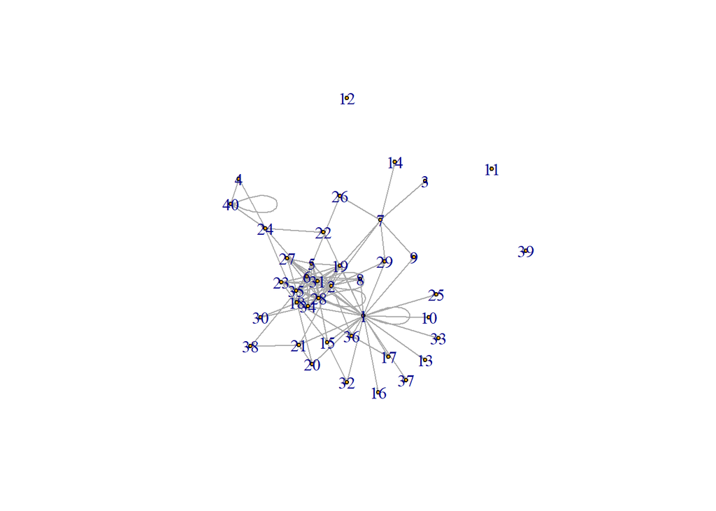

```r
#for tie-type2
#network
edgelist2 = subset(edgelist, tie_type == 2)
newnetwork2 <- graph_from_data_frame(d = edgelist2, vertices = nodelist, directed = TRUE)
plot(newnetwork2, edge.arrow.size = 0.1, vertex.size = 3)
```

```r
#Degree Centrality
degree(newnetwork2, mode="in")
```

```
##  1  2  3  4  5  6  7  8  9 10 11 12 13 14 15 16 17 18 19 20 21 22 23 24 25 26
##  2 10  1  2  7 10  0  4  2  1  0  0  1  1  2  1  1 11  9  2  4  2  4  1  1  2
## 27 28 29 30 31 32 33 34 35 36 37 38 39 40
##  6 11  3  2  9  2  1  7  7  4  1  1  0  2
```

```r
centr_degree(newnetwork2, mode="in", normalized=T)
```

```
## $res
##  [1]  2 10  1  2  7 10  0  4  2  1  0  0  1  1  2  1  1 11  9  2  4  2  4  1  1
## [26]  2  6 11  3  2  9  2  1  7  7  4  1  1  0  2
##
## $centralization
## [1] 0.1942308
##
## $theoretical_max
## [1] 1560
```

```r
degree(newnetwork2, mode="out")
```

```
##  1  2  3  4  5  6  7  8  9 10 11 12 13 14 15 16 17 18 19 20 21 22 23 24 25 26
## 24 12  0  0 10 11  7  0  0  0  0  0  0  0  3  0  1 10  0  1  0  0  6  5  0  0
## 27 28 29 30 31 32 33 34 35 36 37 38 39 40
##  0 13  0  2 11  0  0  7 10  0  0  1  0  3
```

```r
centr_degree(newnetwork2, mode="out", normalized=T)
```

```
## $res
##  [1] 24 12  0  0 10 11  7  0  0  0  0  0  0  0  3  0  1 10  0  1  0  0  6  5  0
## [26]  0  0 13  0  2 11  0  0  7 10  0  0  1  0  3
##
## $centralization
## [1] 0.5275641
##
## $theoretical_max
## [1] 1560
```

```r
degree(newnetwork2, mode="all")
```

```
##  1  2  3  4  5  6  7  8  9 10 11 12 13 14 15 16 17 18 19 20 21 22 23 24 25 26
## 26 22  1  2 17 21  7  4  2  1  0  0  1  1  5  1  2 21  9  3  4  2 10  6  1  2
## 27 28 29 30 31 32 33 34 35 36 37 38 39 40
##  6 24  3  4 20  2  1 14 17  4  1  2  0  5
```

```r
centr_degree(newnetwork2, mode="all", normalized=T)
```

```
## $res
##  [1] 26 22  1  2 17 21  7  4  2  1  0  0  1  1  5  1  2 21  9  3  4  2 10  6  1
## [26]  2  6 24  3  4 20  2  1 14 17  4  1  2  0  5
##
## $centralization
## [1] 0.251808
##
## $theoretical_max
## [1] 3042
```

```r
#Closeness Centrality
closeness(newnetwork2, mode="all", weights=NA)
```

```
##            1            2            3            4            5            6
## 0.0057471264 0.0056179775 0.0042016807 0.0041841004 0.0051020408 0.0055248619
##            7            8            9           10           11           12
## 0.0049261084 0.0051282051 0.0049751244 0.0047846890 0.0006410256 0.0006410256
##           13           14           15           16           17           18
## 0.0047846890 0.0042016807 0.0050761421 0.0047846890 0.0048309179 0.0053191489
##           19           20           21           22           23           24
## 0.0054054054 0.0050505051 0.0050761421 0.0049504950 0.0049751244 0.0048780488
##           25           26           27           28           29           30
## 0.0047846890 0.0045045045 0.0049504950 0.0054347826 0.0051020408 0.0046948357
##           31           32           33           34           35           36
## 0.0054054054 0.0048309179 0.0047846890 0.0052910053 0.0054054054 0.0051546392
##           37           38           39           40
## 0.0047846890 0.0046082949 0.0006410256 0.0041841004
```

```r
#Eigenvector Centrality
eigen_centrality(newnetwork2, directed=T, weights=NA)
```

```
## $vector
##            1            2            3            4            5            6
## 1.563515e-01 8.622710e-01 7.492829e-17 1.835743e-15 7.882987e-01 8.622710e-01
##            7            8            9           10           11           12
## 5.619621e-17 3.748961e-01 2.114045e-02 2.114045e-02 5.619621e-17 5.619621e-17
##           13           14           15           16           17           18
## 2.114045e-02 7.492829e-17 1.563515e-01 2.114045e-02 2.114045e-02 8.869263e-01
##           19           20           21           22           23           24
## 7.961036e-01 1.410627e-01 1.692863e-01 2.114045e-02 4.647085e-01 1.142656e-15
##           25           26           27           28           29           30
## 2.114045e-02 1.065867e-01 6.878837e-01 1.000000e+00 1.377290e-01 2.070017e-01
##           31           32           33           34           35           36
## 8.917801e-01 4.228089e-02 2.114045e-02 6.440264e-01 6.828612e-01 2.605096e-01
##           37           38           39           40
## 2.114045e-02 9.233036e-02 5.619621e-17 1.873207e-15
##
## $value
## [1] 7.395846
##
## $options
## $options$bmat
## [1] "I"
##
## $options$n
## [1] 40
##
## $options$which
## [1] "LR"
##
## $options$nev
## [1] 1
##
## $options$tol
## [1] 0
##
## $options$ncv
## [1] 0
##
## $options$ldv
## [1] 0
```

[output cut: 24 more lines]

```
##
## $options$iter
## [1] 1
##
## $options$nconv
## [1] 1
##
## $options$numop
## [1] 20
##
## $options$numopb
## [1] 0
##
## $options$numreo
## [1] 17
```

```r
#Betweenness Centrality
betweenness(newnetwork2, directed=T, weights=NA)
```

```
##          1          2          3          4          5          6          7
## 132.309524  55.288095   0.000000   0.000000  15.659524  38.004762   0.000000
##          8          9         10         11         12         13         14
##   0.000000   0.000000   0.000000   0.000000   0.000000   0.000000   0.000000
##         15         16         17         18         19         20         21
##   6.642857   0.000000   0.000000  71.945238   0.000000   1.750000   0.000000
##         22         23         24         25         26         27         28
##   0.000000   0.000000  31.000000   0.000000   0.000000   0.000000 166.307143
##         29         30         31         32         33         34         35
##   0.000000   0.000000   6.271429   0.000000   0.000000  15.585714  16.735714
##         36         37         38         39         40
##   0.000000   0.000000   0.500000   0.000000   0.000000
```

```r
#Similarity
assortativity_degree(newnetwork2, directed=T)
```

```
## [1] -0.2405615
```

```r
net2 <- graph_from_data_frame(d = edgelist2,vertices = nodelist,directed = TRUE)
#Remove missing values from nodelist
net2.0 = subgraph(net2, v = nodelist$ID[!is.na(nodelist$personality)])
assortativity_degree(net2.0, directed=T)
```

```
## [1] -0.1777164
```

```r
assortativity(net2.0, V(net2.0)$personality, directed=T)
```

```
## [1] -0.03619892
```

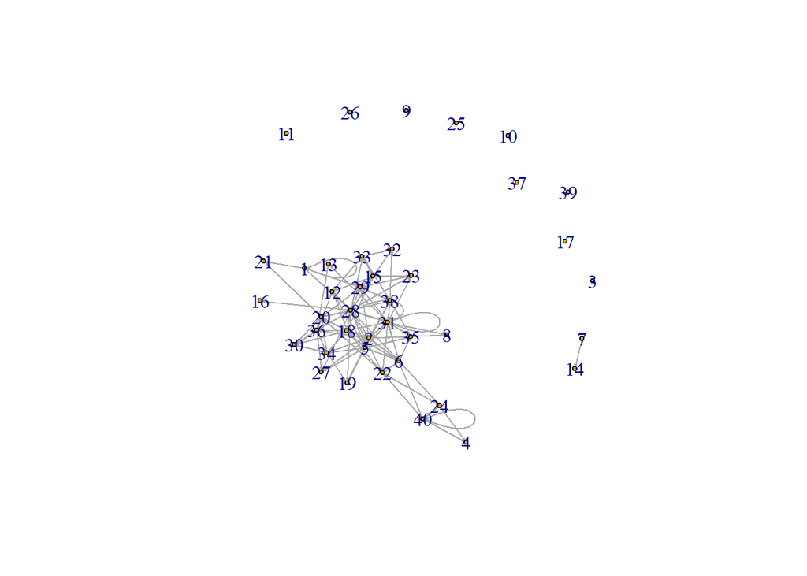

```r
#for tie-type3
#network
edgelist3 = subset(edgelist, tie_type == 3)
newnetwork3 <- graph_from_data_frame(d = edgelist3, vertices = nodelist, directed = TRUE)
plot(newnetwork3, edge.arrow.size = 0.1, vertex.size = 3)
```

```r
#Degree Centrality
degree(newnetwork3, mode="in")
```

```
##  1  2  3  4  5  6  7  8  9 10 11 12 13 14 15 16 17 18 19 20 21 22 23 24 25 26
##  2  9  0  2  8  8  0  2  0  0  0  6  2  1  4  1  0  9  4  6  2  7  3  1  0  0
## 27 28 29 30 31 32 33 34 35 36 37 38 39 40
##  4  7  8  4  8  4  3  6  4  6  0  2  0  2
```

```r
centr_degree(newnetwork3, mode="in", normalized=T)
```

```
## $res
##  [1] 2 9 0 2 8 8 0 2 0 0 0 6 2 1 4 1 0 9 4 6 2 7 3 1 0 0 4 7 8 4 8 4 3 6 4 6 0 2
## [39] 0 2
##
## $centralization
## [1] 0.1442308
##
## $theoretical_max
## [1] 1560
```

```r
degree(newnetwork3, mode="out")
```

```
##  1  2  3  4  5  6  7  8  9 10 11 12 13 14 15 16 17 18 19 20 21 22 23 24 25 26
##  4 11  0  0 10  5  1  0  0  0  0  0  0  0  7  0  0 12  0  7  0  0  1  4  0  0
## 27 28 29 30 31 32 33 34 35 36 37 38 39 40
##  0 19  0  4 12  1  4  7  5  8  0  8  0  5
```

```r
centr_degree(newnetwork3, mode="out", normalized=T)
```

```
## $res
##  [1]  4 11  0  0 10  5  1  0  0  0  0  0  0  0  7  0  0 12  0  7  0  0  1  4  0
## [26]  0  0 19  0  4 12  1  4  7  5  8  0  8  0  5
##
## $centralization
## [1] 0.400641
##
## $theoretical_max
## [1] 1560
```

```r
degree(newnetwork3, mode="all")
```

```
##  1  2  3  4  5  6  7  8  9 10 11 12 13 14 15 16 17 18 19 20 21 22 23 24 25 26
##  6 20  0  2 18 13  1  2  0  0  0  6  2  1 11  1  0 21  4 13  2  7  4  5  0  0
## 27 28 29 30 31 32 33 34 35 36 37 38 39 40
##  4 26  8  8 20  5  7 13  9 14  0 10  0  7
```

```r
centr_degree(newnetwork3, mode="all", normalized=T)
```

```
## $res
##  [1]  6 20  0  2 18 13  1  2  0  0  0  6  2  1 11  1  0 21  4 13  2  7  4  5  0
## [26]  0  4 26  8  8 20  5  7 13  9 14  0 10  0  7
##
## $centralization
## [1] 0.2531229
##
## $theoretical_max
## [1] 3042
```

```r
#Closeness Centrality
closeness(newnetwork3, mode="all", weights=NA)
```

```
##            1            2            3            4            5            6
## 0.0019920319 0.0020618557 0.0006410256 0.0018691589 0.0020533881 0.0020491803
##            7            8            9           10           11           12
## 0.0006574622 0.0019685039 0.0006410256 0.0006410256 0.0006410256 0.0020161290
##           13           14           15           16           17           18
## 0.0019801980 0.0006574622 0.0020120724 0.0019762846 0.0006410256 0.0020618557
##           19           20           21           22           23           24
## 0.0020080321 0.0020449898 0.0019455253 0.0020449898 0.0020040080 0.0019646365
##           25           26           27           28           29           30
## 0.0006410256 0.0006410256 0.0020120724 0.0020876827 0.0020325203 0.0019880716
##           31           32           33           34           35           36
## 0.0020576132 0.0019960080 0.0020000000 0.0020080321 0.0020120724 0.0020366599
##           37           38           39           40
## 0.0006410256 0.0020283976 0.0006410256 0.0019646365
```

```r
#Eigenvector Centrality
eigen_centrality(newnetwork3, directed=T, weights=NA)
```

```
## $vector
##            1            2            3            4            5            6
## 1.229661e-01 1.000000e+00 2.050810e-17 8.203240e-17 9.048247e-01 7.757240e-01
##            7            8            9           10           11           12
## 2.050810e-17 3.036690e-01 2.050810e-17 2.050810e-17 2.050810e-17 5.928422e-01
##           13           14           15           16           17           18
## 2.566020e-01 0.000000e+00 3.238540e-01 1.036353e-01 2.050810e-17 9.940815e-01
##           19           20           21           22           23           24
## 5.184636e-01 5.941449e-01 1.127328e-01 6.217230e-01 3.010113e-01 0.000000e+00
##           25           26           27           28           29           30
## 2.050810e-17 2.050810e-17 5.132189e-01 6.592400e-01 6.522826e-01 4.751950e-01
##           31           32           33           34           35           36
## 9.316850e-01 2.182030e-01 1.885605e-01 7.339621e-01 4.446681e-01 7.005999e-01
##           37           38           39           40
## 2.050810e-17 2.163685e-01 2.050810e-17 8.203240e-17
##
## $value
## [1] 6.361154
##
## $options
## $options$bmat
## [1] "I"
##
## $options$n
## [1] 40
##
## $options$which
## [1] "LR"
##
## $options$nev
## [1] 1
##
## $options$tol
## [1] 0
##
## $options$ncv
## [1] 0
##
## $options$ldv
## [1] 0
```

[output cut: 24 more lines]

```
##
## $options$iter
## [1] 1
##
## $options$nconv
## [1] 1
##
## $options$numop
## [1] 20
##
## $options$numopb
## [1] 0
##
## $options$numreo
## [1] 17
```

```r
#Betweenness Centrality
betweenness(newnetwork3, directed=T, weights=NA)
```

```
##           1           2           3           4           5           6
##   2.6166667  53.4119048   0.0000000   0.0000000  39.3690476  52.1190476
##           7           8           9          10          11          12
##   0.0000000   0.0000000   0.0000000   0.0000000   0.0000000   0.0000000
##          13          14          15          16          17          18
##   0.0000000   0.0000000  31.6261905   0.0000000   0.0000000  70.6142857
##          19          20          21          22          23          24
##   0.0000000  21.2928571   0.0000000   0.0000000   0.0000000   0.0000000
##          25          26          27          28          29          30
##   0.0000000   0.0000000   0.0000000 110.6809524   0.0000000   0.0000000
##          31          32          33          34          35          36
##  49.3833333   0.6428571   2.1428571  10.3952381   4.5500000  15.2928571
##          37          38          39          40
##   0.0000000  11.8619048   0.0000000   0.0000000
```

```r
#Similarity
assortativity_degree(newnetwork3, directed=T)
```

```
## [1] 0.02809497
```

```r
net3 <- graph_from_data_frame(d = edgelist3,vertices = nodelist,directed = TRUE)
#Remove missing values from nodelist
net3.0 = subgraph(net3, v = nodelist$ID[!is.na(nodelist$personality)])
assortativity_degree(net3.0, directed=T)
```

```
## [1] 0.07338665
```

```r
assortativity(net3.0, V(net3.0)$personality, directed=T)
```

```
## [1] 0.0489798
```

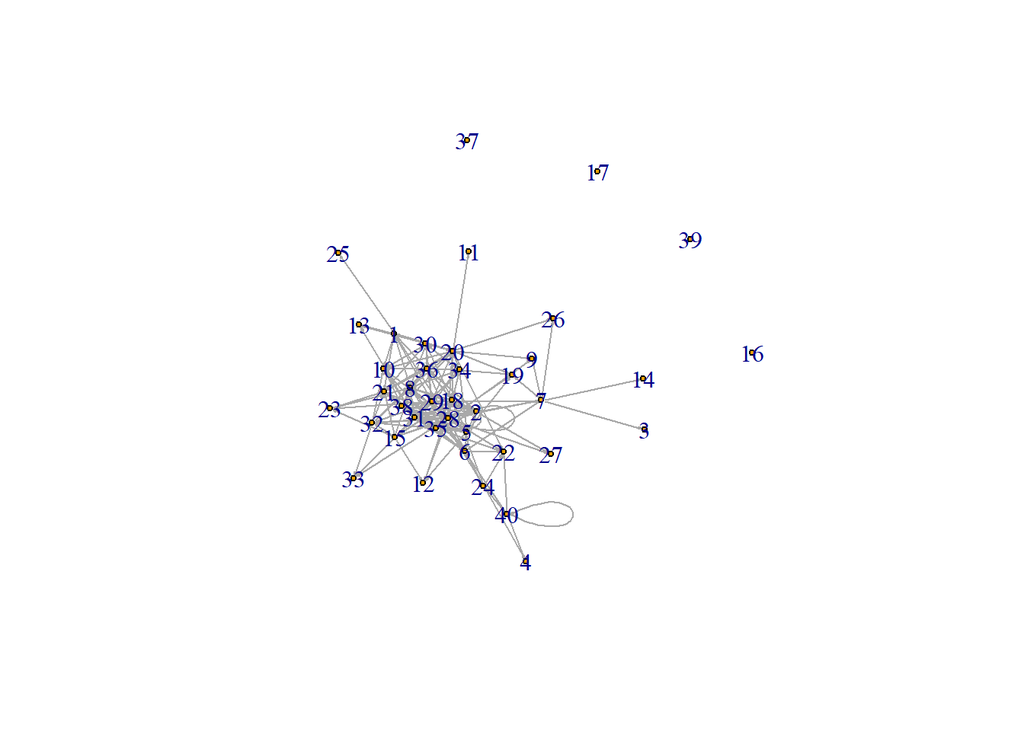

```r
#for tie-type4
#network
edgelist4 = subset(edgelist, tie_type == 4)
newnetwork4 <- graph_from_data_frame(d = edgelist4, vertices = nodelist, directed = TRUE)
plot(newnetwork4, edge.arrow.size = 0.1, vertex.size = 3)
```

```r
#Degree Centrality
degree(newnetwork4, mode="in")
```

```
##  1  2  3  4  5  6  7  8  9 10 11 12 13 14 15 16 17 18 19 20 21 22 23 24 25 26
##  1  9  1  2  8  8  1 15  3  9  1  4  3  1  2  0  0  9  5  6 12  6  1  1  1  2
## 27 28 29 30 31 32 33 34 35 36 37 38 39 40
##  2 11 16  4  7  3  3  5  4  8  0  2  0  3
```

```r
centr_degree(newnetwork4, mode="in", normalized=T)
```

```
## $res
##  [1]  1  9  1  2  8  8  1 15  3  9  1  4  3  1  2  0  0  9  5  6 12  6  1  1  1
## [26]  2  2 11 16  4  7  3  3  5  4  8  0  2  0  3
##
## $centralization
## [1] 0.2955128
##
## $theoretical_max
## [1] 1560
```

```r
degree(newnetwork4, mode="out")
```

```
##  1  2  3  4  5  6  7  8  9 10 11 12 13 14 15 16 17 18 19 20 21 22 23 24 25 26
##  9  9  0  0  8  9  9  0  0  0  0  0  0  0 10  0  0 10  0 16  0  0  3  7  0  0
## 27 28 29 30 31 32 33 34 35 36 37 38 39 40
##  0 19  0  8 11  7  0  8 12  9  0 10  0  5
```

```r
centr_degree(newnetwork4, mode="out", normalized=T)
```

```
## $res
##  [1]  9  9  0  0  8  9  9  0  0  0  0  0  0  0 10  0  0 10  0 16  0  0  3  7  0
## [26]  0  0 19  0  8 11  7  0  8 12  9  0 10  0  5
##
## $centralization
## [1] 0.3724359
##
## $theoretical_max
## [1] 1560
```

```r
degree(newnetwork4, mode="all")
```

```
##  1  2  3  4  5  6  7  8  9 10 11 12 13 14 15 16 17 18 19 20 21 22 23 24 25 26
## 10 18  1  2 16 17 10 15  3  9  1  4  3  1 12  0  0 19  5 22 12  6  4  8  1  2
## 27 28 29 30 31 32 33 34 35 36 37 38 39 40
##  2 30 16 12 18 10  3 13 16 17  0 12  0  8
```

```r
centr_degree(newnetwork4, mode="all", normalized=T)
```

```
## $res
##  [1] 10 18  1  2 16 17 10 15  3  9  1  4  3  1 12  0  0 19  5 22 12  6  4  8  1
## [26]  2  2 30 16 12 18 10  3 13 16 17  0 12  0  8
##
## $centralization
## [1] 0.2767916
##
## $theoretical_max
## [1] 3042
```

```r
#Closeness Centrality
closeness(newnetwork4, mode="all", weights=NA)
```

```
##            1            2            3            4            5            6
## 0.0044444444 0.0045248869 0.0038610039 0.0038022814 0.0044052863 0.0045454545
##            7            8            9           10           11           12
## 0.0044444444 0.0045871560 0.0042194093 0.0044247788 0.0040000000 0.0042553191
##           13           14           15           16           17           18
## 0.0041322314 0.0038610039 0.0043668122 0.0006410256 0.0006410256 0.0045045045
##           19           20           21           22           23           24
## 0.0043668122 0.0046296296 0.0045248869 0.0043859649 0.0041666667 0.0043478261
##           25           26           27           28           29           30
## 0.0038610039 0.0041322314 0.0041666667 0.0048076923 0.0046728972 0.0043668122
##           31           32           33           34           35           36
## 0.0044444444 0.0043668122 0.0042194093 0.0044052863 0.0044642857 0.0045045045
##           37           38           39           40
## 0.0006410256 0.0044444444 0.0006410256 0.0040485830
```

```r
#Eigenvector Centrality
eigen_centrality(newnetwork4, directed=T, weights=NA)
```

```
## $vector
##          1          2          3          4          5          6          7
## 0.06106658 0.74441360 0.01864891 0.02309534 0.69842913 0.56184247 0.11090174
##          8          9         10         11         12         13         14
## 1.00000000 0.13823234 0.56320516 0.06106658 0.37821407 0.17939078 0.01864891
##         15         16         17         18         19         20         21
## 0.22323050 0.00000000 0.00000000 0.66799906 0.36902288 0.36315202 0.70153297
##         22         23         24         25         26         27         28
## 0.34805829 0.03753778 0.01977075 0.01026878 0.07971549 0.23608014 0.65951281
##         29         30         31         32         33         34         35
## 0.90964474 0.33038324 0.64258630 0.20695638 0.18324070 0.36251743 0.34798930
##         36         37         38         39         40
## 0.57106157 0.00000000 0.16657228 0.00000000 0.11757312
##
## $value
## [1] 5.946821
##
## $options
## $options$bmat
## [1] "I"
##
## $options$n
## [1] 40
##
## $options$which
## [1] "LR"
##
## $options$nev
## [1] 1
##
## $options$tol
## [1] 0
##
## $options$ncv
## [1] 0
##
## $options$ldv
## [1] 0
##
## $options$ishift
```

[output cut: 22 more lines]

```
##
## $options$iter
## [1] 1
##
## $options$nconv
## [1] 1
##
## $options$numop
## [1] 20
##
## $options$numopb
## [1] 0
##
## $options$numreo
## [1] 20
```

```r
#Betweenness Centrality
betweenness(newnetwork4, directed=T, weights=NA)
```

```
##          1          2          3          4          5          6          7
##  17.000000  44.688095   0.000000   0.000000  41.119048  69.800000  40.285714
##          8          9         10         11         12         13         14
##   0.000000   0.000000   0.000000   0.000000   0.000000   0.000000   0.000000
##         15         16         17         18         19         20         21
##  20.492857   0.000000   0.000000  74.135714   0.000000  94.532143   0.000000
##         22         23         24         25         26         27         28
##   0.000000   0.000000  18.666667   0.000000   0.000000   0.000000 166.645238
##         29         30         31         32         33         34         35
##   0.000000   1.259524  27.126190   4.566667   0.000000   9.326190  17.392857
##         36         37         38         39         40
##  26.860714   0.000000  16.102381   0.000000  32.000000
```

```r
#Similarity measure
assortativity_degree(newnetwork4, directed=T)
```

```
## [1] -0.1294851
```

```r
net4 <- graph_from_data_frame(d = edgelist4,vertices = nodelist,directed = TRUE)
#Remove missing values from nodelist
net4.0 = subgraph(net4, v = nodelist$ID[!is.na(nodelist$personality)])
assortativity_degree(net4.0, directed=T)
```

```
## [1] -0.09199292
```

```r
assortativity(net4.0, V(net4.0)$personality, directed=T)
```

```
## [1] 0.1425414
```

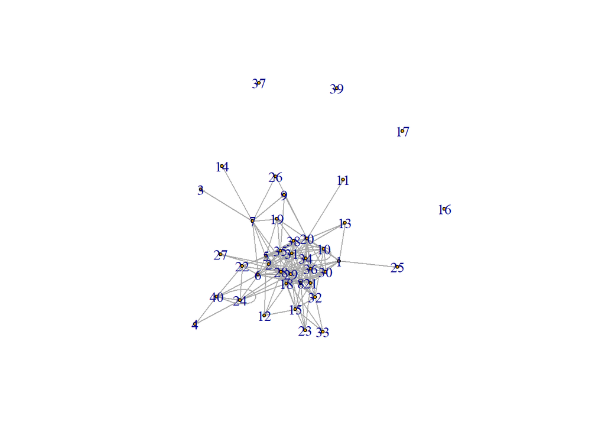

```r
#for tie-type5
#network
edgelist5 = subset(edgelist, tie_type == 5)
newnetwork5 <- graph_from_data_frame(d = edgelist5, vertices = nodelist, directed = TRUE)
plot(newnetwork4, edge.arrow.size = 0.1, vertex.size = 3)
```

```r
#Degree Centrality
degree(newnetwork5, mode="in")
```

```
##  1  2  3  4  5  6  7  8  9 10 11 12 13 14 15 16 17 18 19 20 21 22 23 24 25 26
##  4  2  1  2  7  8  0  0  4  0  1  2  2  1  1  0  0  8  4  5  1  7  1  2  0  3
## 27 28 29 30 31 32 33 34 35 36 37 38 39 40
##  1  9  3  4  6  2  3  5  5  5  0  2  0  3
```

```r
centr_degree(newnetwork5, mode="in", normalized=T)
```

```
## $res
##  [1] 4 2 1 2 7 8 0 0 4 0 1 2 2 1 1 0 0 8 4 5 1 7 1 2 0 3 1 9 3 4 6 2 3 5 5 5 0 2
## [39] 0 3
##
## $centralization
## [1] 0.1576923
##
## $theoretical_max
## [1] 1560
```

```r
degree(newnetwork5, mode="out")
```

```
##  1  2  3  4  5  6  7  8  9 10 11 12 13 14 15 16 17 18 19 20 21 22 23 24 25 26
##  0 10  0  0  4  7  7  0  0  0  0  0  0  0  9  0  0  8  0 13  0  0  0  7  0  0
## 27 28 29 30 31 32 33 34 35 36 37 38 39 40
##  0 11  0  4  5  3  0  6  6  4  0  4  0  6
```

```r
centr_degree(newnetwork5, mode="out", normalized=T)
```

```
## $res
##  [1]  0 10  0  0  4  7  7  0  0  0  0  0  0  0  9  0  0  8  0 13  0  0  0  7  0
## [26]  0  0 11  0  4  5  3  0  6  6  4  0  4  0  6
##
## $centralization
## [1] 0.2602564
##
## $theoretical_max
## [1] 1560
```

```r
degree(newnetwork5, mode="all")
```

```
##  1  2  3  4  5  6  7  8  9 10 11 12 13 14 15 16 17 18 19 20 21 22 23 24 25 26
##  4 12  1  2 11 15  7  0  4  0  1  2  2  1 10  0  0 16  4 18  1  7  1  9  0  3
## 27 28 29 30 31 32 33 34 35 36 37 38 39 40
##  1 20  3  8 11  5  3 11 11  9  0  6  0  9
```

```r
centr_degree(newnetwork5, mode="all", normalized=T)
```

```
## $res
##  [1]  4 12  1  2 11 15  7  0  4  0  1  2  2  1 10  0  0 16  4 18  1  7  1  9  0
## [26]  3  1 20  3  8 11  5  3 11 11  9  0  6  0  9
##
## $centralization
## [1] 0.1880342
##
## $theoretical_max
## [1] 3042
```

```r
#Closeness Centrality
closeness(newnetwork5, mode="all", weights=NA)
```

```
##            1            2            3            4            5            6
## 0.0028818444 0.0029411765 0.0026455026 0.0026666667 0.0029239766 0.0029498525
##            7            8            9           10           11           12
## 0.0028818444 0.0006410256 0.0028571429 0.0006410256 0.0027173913 0.0027700831
##           13           14           15           16           17           18
## 0.0027777778 0.0026455026 0.0028985507 0.0006410256 0.0006410256 0.0029761905
##           19           20           21           22           23           24
## 0.0028818444 0.0029673591 0.0026954178 0.0029325513 0.0026595745 0.0028901734
##           25           26           27           28           29           30
## 0.0006410256 0.0028409091 0.0026954178 0.0030303030 0.0028089888 0.0028169014
##           31           32           33           34           35           36
## 0.0029069767 0.0028409091 0.0028169014 0.0029069767 0.0028571429 0.0028571429
##           37           38           39           40
## 0.0006410256 0.0028169014 0.0006410256 0.0028089888
```

```r
#Eigenvector Centrality
eigen_centrality(newnetwork5, directed=T, weights=NA)
```

```
## $vector
##          1          2          3          4          5          6          7
## 0.37114373 0.34893223 0.00000000 0.11906264 1.00000000 0.97908483 0.00000000
##          8          9         10         11         12         13         14
## 0.00000000 0.30838203 0.00000000 0.10430561 0.18362373 0.27697988 0.00000000
##         15         16         17         18         19         20         21
## 0.16880615 0.00000000 0.00000000 0.73124670 0.37247734 0.51126598 0.07118719
##         22         23         24         25         26         27         28
## 0.76539526 0.03443888 0.26478922 0.00000000 0.17549281 0.07118719 0.82742279
##         29         30         31         32         33         34         35
## 0.12520800 0.45844843 0.84638279 0.20324503 0.24470994 0.48705181 0.68149403
##         36         37         38         39         40
## 0.51757330 0.00000000 0.31170885 0.00000000 0.31881003
##
## $value
## [1] 4.901615
##
## $options
## $options$bmat
## [1] "I"
##
## $options$n
## [1] 40
##
## $options$which
## [1] "LR"
##
## $options$nev
## [1] 1
##
## $options$tol
## [1] 0
##
## $options$ncv
## [1] 0
##
## $options$ldv
## [1] 0
##
## $options$ishift
```

[output cut: 22 more lines]

```
##
## $options$iter
## [1] 1
##
## $options$nconv
## [1] 1
##
## $options$numop
## [1] 20
##
## $options$numopb
## [1] 0
##
## $options$numreo
## [1] 17
```

```r
#Betweenness Centrality
betweenness(newnetwork5, directed=T, weights=NA)
```

```
##          1          2          3          4          5          6          7
##   0.000000  59.643651   0.000000   0.000000  28.055556  92.634921   0.000000
##          8          9         10         11         12         13         14
##   0.000000   0.000000   0.000000   0.000000   0.000000   0.000000   0.000000
##         15         16         17         18         19         20         21
##  20.400000   0.000000   0.000000  83.031746   0.000000  84.061905   0.000000
##         22         23         24         25         26         27         28
##   0.000000   0.000000  30.661905   0.000000   0.000000   0.000000 125.377778
##         29         30         31         32         33         34         35
##   0.000000   0.000000  23.719048   2.500000   0.000000   7.861111  22.852381
##         36         37         38         39         40
##   3.233333   0.000000  17.633333   0.000000   9.333333
```

```r
#Similarity measure
assortativity_degree(newnetwork5, directed=T)
```

```
## [1] -0.06440357
```

```r
net5 <- graph_from_data_frame(d = edgelist5,vertices = nodelist,directed = TRUE)
#Remove missing values from nodelist
net5.0 = subgraph(net5, v = nodelist$ID[!is.na(nodelist$personality)])
assortativity_degree(net5.0, directed=T)
```

```
## [1] -0.1073296
```

```r
assortativity(net5.0, V(net5.0)$personality, directed=T)
```

```
## [1] 0.1132533
```

Which tie type generates the most similar network in terms of introversion?

```r
nodelist$introvert = nodelist$personality == 1

net1.1 <- graph_from_data_frame(d = edgelist1, vertices = nodelist, directed = TRUE)
net2.1 <- graph_from_data_frame(d = edgelist2, vertices = nodelist, directed = TRUE)
net3.1 <- graph_from_data_frame(d = edgelist3, vertices = nodelist, directed = TRUE)
net4.1 <- graph_from_data_frame(d = edgelist4, vertices = nodelist, directed = TRUE)
net5.1 <- graph_from_data_frame(d = edgelist5, vertices = nodelist, directed = TRUE)

net1.2 = subgraph(net1.1, v = nodelist$ID[!is.na(nodelist$introvert)])
net2.2 = subgraph(net2.1, v = nodelist$ID[!is.na(nodelist$introvert)])
net3.2 = subgraph(net3.1, v = nodelist$ID[!is.na(nodelist$introvert)])
net4.2 = subgraph(net4.1, v = nodelist$ID[!is.na(nodelist$introvert)])
net5.2 = subgraph(net5.1, v = nodelist$ID[!is.na(nodelist$introvert)])
assortativity(net1.2, V(net1.2)$introvert, directed=T)
```

```
## [1] 0.05279815
```

```r
assortativity(net2.2, V(net2.2)$introvert, directed=T)
```

```
## [1] -0.08302011
```

```r
assortativity(net3.2, V(net3.2)$introvert, directed=T)
```

```
## [1] -0.03849002
```

```r
assortativity(net4.2, V(net4.2)$introvert, directed=T)
```

```
## [1] -0.03849002
```

```r
assortativity(net5.2, V(net5.2)$introvert, directed=T)
```

```
## [1] -0.005574136
```

According to the output, tie-type 1 generates the most similar network in terms of introversion, and tie-type 2 generates the most dissimilar network.

#3) Do introverts tend to be at the periphery while extraverts are in the center of the network? Motivate.

```r
# using regression model
# DV is betweenness centrality, IV is whether introverts or extraverts
newnetwork <- graph_from_data_frame(d = edgelist, vertices = nodelist, directed = TRUE)
modeldata <- nodelist %>%
  mutate(centrality = betweenness(newnetwork, directed=T, weights=NA))
dplyr::filter(modeldata, personality %in% c("1","3")) -> modeldata
model1 <- lm(`centrality` ~ personality, data = modeldata)
summary(model1)
```

```
##
## Call:
## lm(formula = centrality ~ personality, data = modeldata)
##
## Residuals:
##       1       2       3       4       5       6
##   3.628 -17.134  28.476  -1.553 -11.342  -2.075
##
## Coefficients:
##             Estimate Std. Error t value Pr(>|t|)
## (Intercept)   46.789     16.156   2.896   0.0443 *
## personality   -7.292      7.225  -1.009   0.3700
## ---
## Signif. codes:  0 '***' 0.001 '**' 0.01 '*' 0.05 '.' 0.1 ' ' 1
##
## Residual standard error: 17.7 on 4 degrees of freedom
## Multiple R-squared:  0.2029, Adjusted R-squared:  0.003676
## F-statistic: 1.018 on 1 and 4 DF,  p-value: 0.37
```

The model shows a negative but statistically insignificant relationship between personality and centrality. Therefore, we cannot say introverts tend to be at the periphery while extraverts are in the center of the network. A major reason for this result should be that the sample size is too small. There are only 6 participants chose “Introverted” or “Extraverted” for the introversion question.